# Gaze-Xsit Visualizations

```r
rm(list = ls())
knitr::opts_chunk$set(echo=T, warning=F, cache=F, message=F, sanitize = T)
source("../helper_functions/helper_functions.R")
source("../helper_functions/ewma_helper_funs.R")
```

This script munges and analyzes the data for a project exploring the association between allocation of attention and cross-situational word learning in more or less ambiguous contexts.

Read data.

```r
d <- read_csv("../../data/3_tidy_data/gaze_xsit_tidy_trial_level.csv")
d_time <- read_csv("../../data/3_tidy_data/gaze_xsit_tidy_timecourse.csv")
```

## Descriptives

Number of participants in each condition

```r
d %>%
  select(subid, condition) %>%
  unique() %>%
  group_by(condition) %>%
  summarise(n_subs = n()) %>%
  kable()
```

| condition | n_subs |
| --- | --- |
| gaze | 15 |
| no-gaze | 15 |

## Proportion looking plot

Plot proportion correct and incorrect looking on exposure trials (looking at the object that will show up again at test) for each ss for each trial. We will use this to predict correct looking at test.

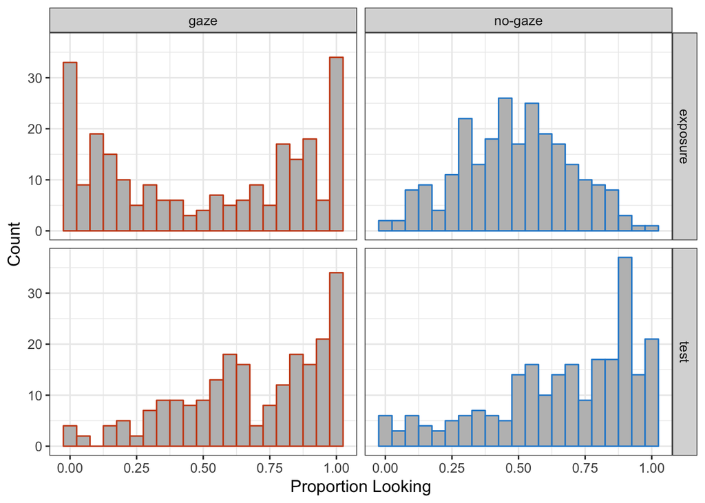

```r
d %>%
  distinct(subid, trial_num, trial_type, .keep_all = T) %>%
  ggplot(aes(x = m_correct, color = condition)) +
  geom_histogram(binwidth = 0.05, fill = "grey") +
  guides(color=F) +
  xlab("Proportion Looking") +
  ylab("Count") +
  theme(text = element_text(size=12)) +
  facet_grid(trial_type ~ condition) +
  langcog::scale_color_solarized()
```

The distribution of correct looking is bimodal for the gaze condition and unimodal for the no-gaze condition. This makes sense and provides evidence that people were following gaze, and that they were distributing attention more broadly in the no-gaze condition.

Next we want to do a sanity check, that is, we want to make sure people were actually following gaze in the gaze condition.

## Gaze following plot

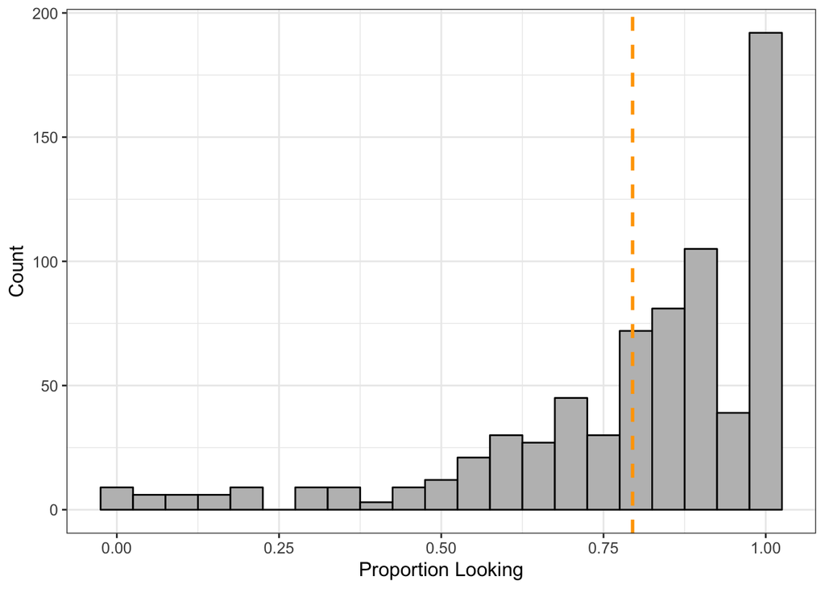

```r
gf_mean <- d %>%
  filter(trial_type == "exposure", condition == "gaze") %>%
  ungroup() %>%
  summarise(m = mean(m_gaze_follow, na.rm = T)) %>%
  pull()

d %>%
  filter(trial_type == "exposure", condition == "gaze") %>%
  ggplot(aes(x=m_gaze_follow)) +
  geom_histogram(fill = "grey", color = "black", binwidth = 0.05) +
  xlab("Proportion Looking") +
  ylab("Count") +
  geom_vline(xintercept = gf_mean,
             color = "orange",
             linetype = "dashed",
             size = 1) +
  theme(text = element_text(size=12))
```

Proportion gaze following on exposure trials in the gaze condition is around a mean of 80%. And the distribution is skewed towards 1, meaning people followed gaze.

## Relationship between looking on exposure and test performance

```r
ss_test <- d_time %>%
  filter(trial.type != "familiar",
         ss_looking_char %in% c("left", "right")) %>%
  group_by(subid, condition, trial_num = as.numeric(trial_num), trial.type) %>%
  summarise(n = n(),
            mean_accuracy = mean(correct)) %>%
  select(-n) %>%
  spread(trial.type, mean_accuracy)
```

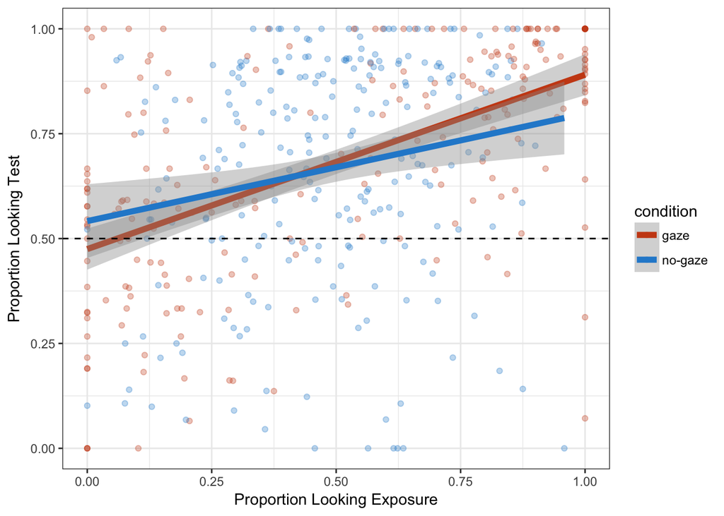

```r
# plot the relation between acc on exposure and acc on test
ss_test %>%
  ggplot(aes(x = exposure, y = test, color = condition)) +
  geom_point(alpha = 0.3) +
  geom_smooth(method = "lm", se = T, size = 2) +
  langcog::scale_color_solarized() +
  geom_hline(yintercept = 0.5, lty = "dashed") +
  labs(y = c("Proportion Looking Test"),
       x = c("Proportion Looking Exposure"))
```

## Frequency of gaze shifts

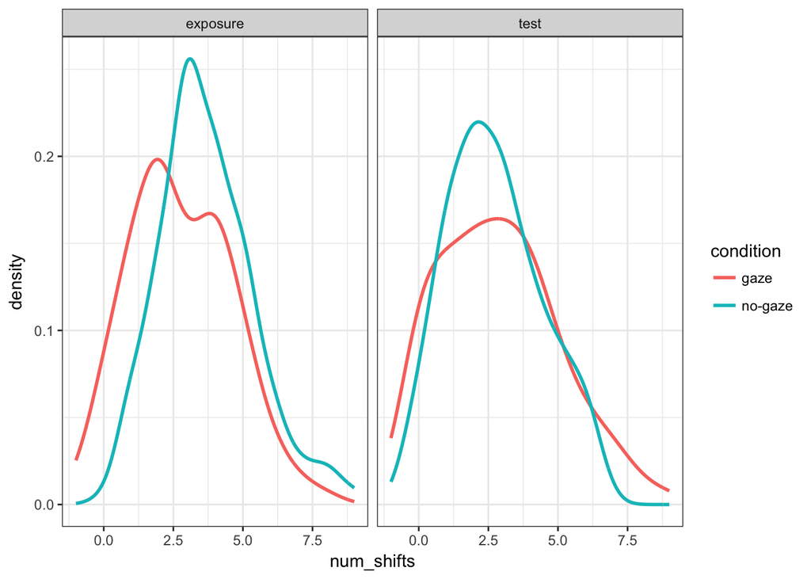

```r
d %>%
  ggplot(aes(x = num_shifts)) +
  geom_line(aes(col = condition), stat = "density", adjust = 1.5, size = 1) +
  facet_wrap(~trial_type)
```

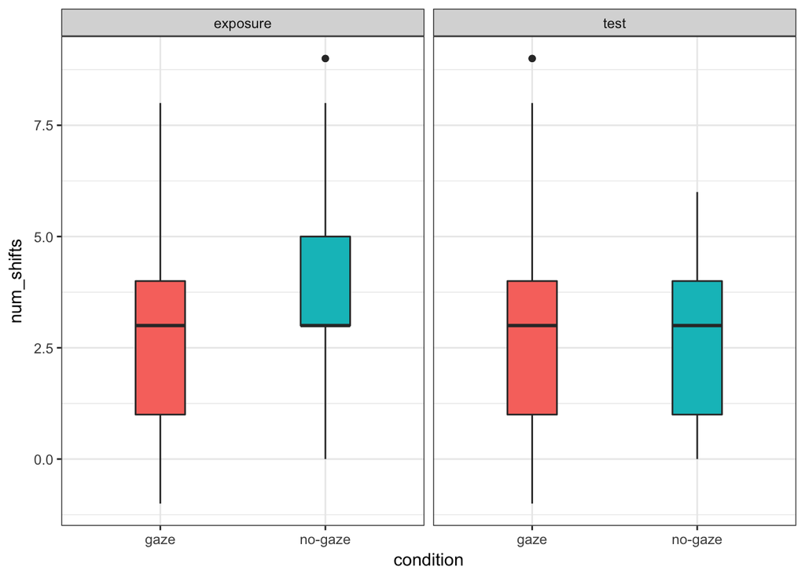

```r
d %>%
  select(subid, trial_num, trial_type, condition, num_shifts) %>%
  unique() %>%
  ggplot(aes(x = condition, y = num_shifts, fill = condition)) +
  geom_boxplot(width = 0.3) +
  guides(fill=F) +
  facet_wrap(~trial_type)
```

Some evidence of more shifting on exposure trials in the no-gaze condition, which makes sense considering the broader allocation of attention.

## Proportion looking to the speaker

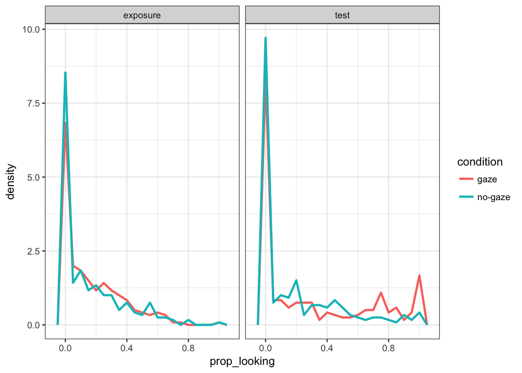

```r
d %>%
  filter(ss_looking_char == "face") %>%
  ggplot(aes(x = prop_looking, ..density.., color = condition)) +
  geom_freqpoly(binwidth = .05, size = 1) +
  facet_wrap(~trial_type)
```

Make a boxplot to summarize looking to face for the different trials and conditions.

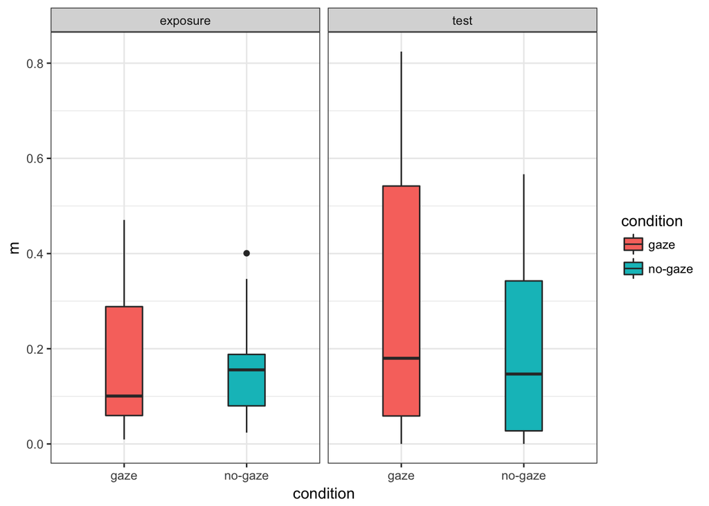

```r
d %>%
  filter(ss_looking_char == "face") %>%
  group_by(subid, condition, trial_type) %>%
  summarise(m = mean(prop_looking)) %>%
  ggplot(aes(x = condition, y = m, fill = condition)) +
  geom_boxplot(width = 0.3, notch = F) +
  facet_wrap(~trial_type)
```

Attention allocated to the speaker seems similar across conditions.

## First shift behavior

```r
d_fst_shift <- d %>% filter(shift_start == "face", rt <= 2.5)
```

Plot distribution of first shift RTs.

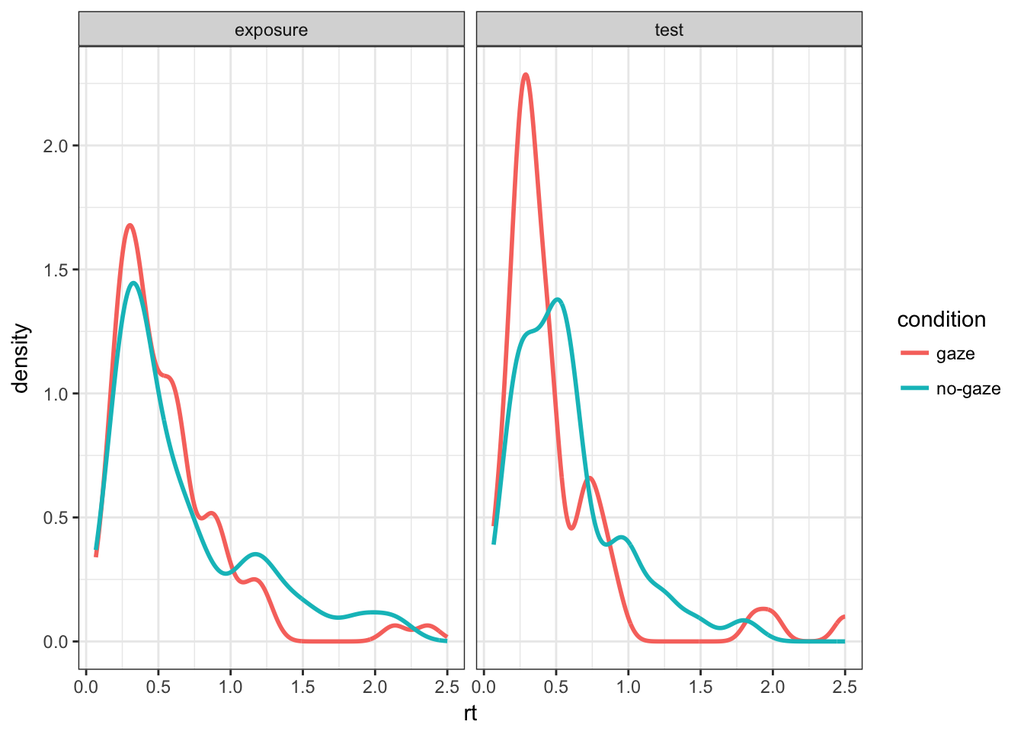

```r
ggplot(data = d_fst_shift, aes(x = rt, col = condition)) +
  geom_line(stat = "density", size = 1) +
  facet_wrap(~trial_type)
```

Time to disengage from the face across conditions (if you happened to be there at the start of the trial out on the face)

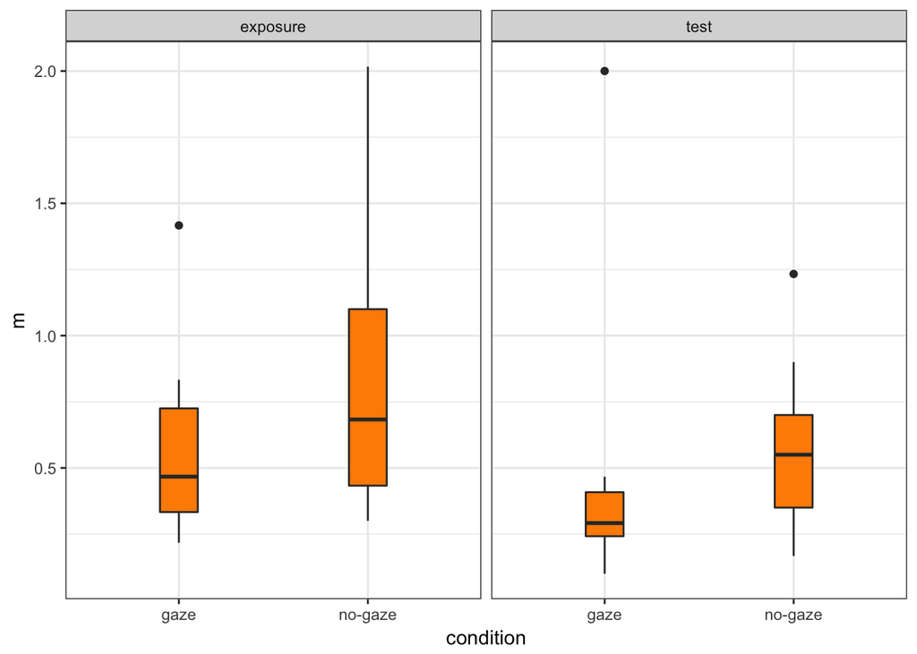

```r
d_fst_shift %>%
  group_by(subid, trial_type, condition) %>%
  summarise(m = median(rt)) %>%
  ggplot(aes(x = condition, y = m)) +
  geom_boxplot(width = 0.2, fill = "darkorange") +
  facet_wrap(~trial_type)
```

It looks like an a main effect of condition and trial type. You are faster to shift away on test trials and in the gaze condition. My first thought is that since the gaze cue starts at the beginning of the trial, it tells you where to look, making you faster to leave the face; whereas you might stick on the face in the no-gaze because of the expectation of useful information.

This suggests that the timing to disengage measure is different depending on when a speaker provides a useful cue to reference.

Any evidence of a speed accuracy tradeoff?

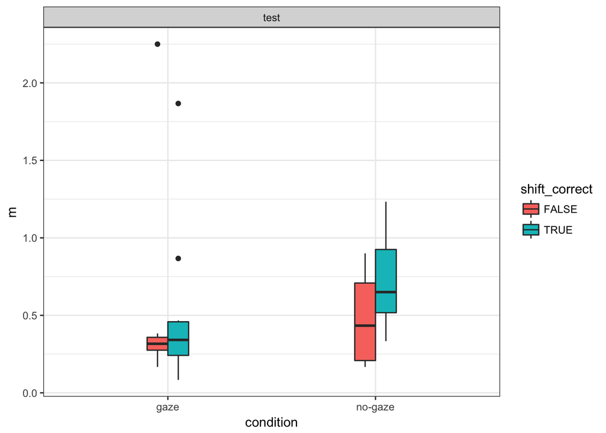

```r
d_fst_shift %>%
  filter(trial_type == "test") %>%
  group_by(subid, trial_type, condition, shift_correct) %>%
  summarise(m = median(rt)) %>%
  ggplot(aes(x = condition, y = m, fill = shift_correct)) +
  geom_boxplot(width = 0.2) +
  facet_wrap(~trial_type)
```

First shift accuracy on test trials

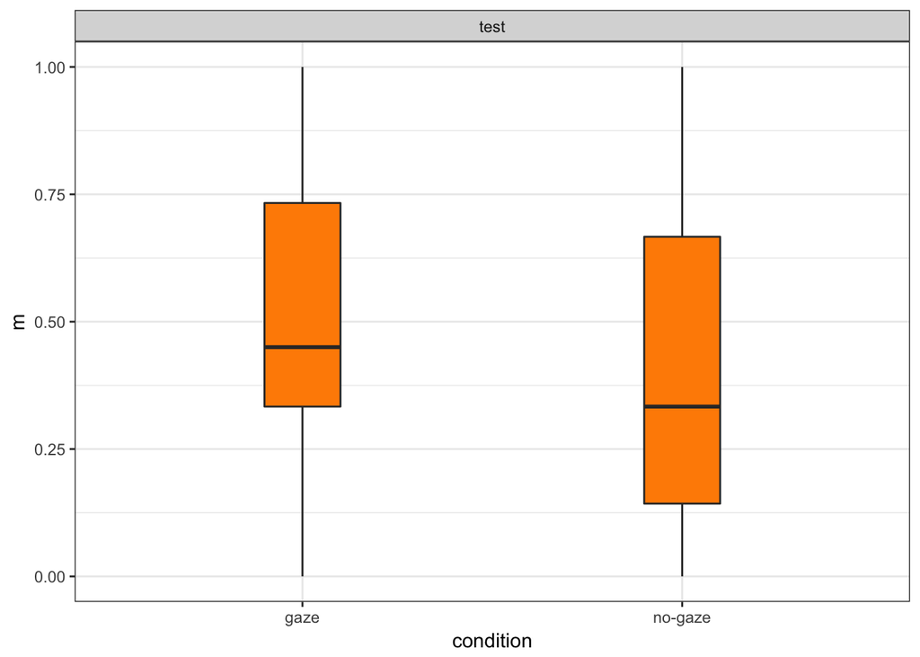

```r
d_fst_shift %>%
  filter(trial_type == "test") %>%
  group_by(subid, trial_type, condition) %>%
  summarise(m = mean(shift_correct)) %>%
  ggplot(aes(x = condition, y = m)) +
  geom_boxplot(width = 0.2, fill = "darkorange") +
  facet_wrap(~trial_type)
```

Overall, looks like random shifts away from the speaker on test trials.

What about first shift accuracy as a function of RT?

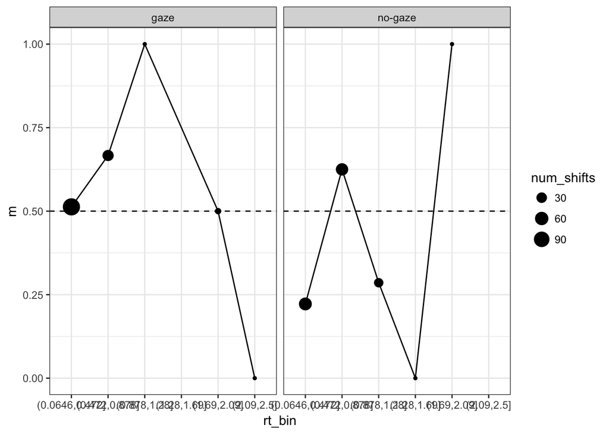

```r
d_fst_shift %>%
  filter(trial_type == "test") %>%
  mutate(rt_bin = cut(rt, breaks = 6)) %>%
  group_by(rt_bin, condition) %>%
  summarise(m = mean(shift_correct),
            num_shifts = n()) %>%
  ggplot(aes(x = rt_bin, y = m)) +
  geom_point(aes(size = num_shifts)) +
  geom_hline(yintercept = 0.5, lty = "dashed") +
  geom_line(group = 1) +
  facet_wrap(~condition)
```

Hmm, tough to interpret accuracy here. Maybe this is a good place for the EWMA approach to model switching accuracy as a function of time?

## EWMA model

Set model parameters (taken from prior work, e.g., Vanderkerchove et al., 2011)

```r
L <- 2
lambda <- .01
cs <- 0.5
sig <- 0.5
```

Fit model. Note that I had to use a really small value for the $L$ threshold parameter to even detect any deviation from guessing in these first shifts.

```r
ewma_results <- d_fst_shift %>%
  filter(trial_type == "test") %>%
  select(subid, condition, rt, shift_correct, shift_start, shift_end, trial_num) %>%
  unique() %>%
  group_by(condition) %>%
  do(fit_ewma(., rt_column = "rt", acc_column = "shift_correct",
              L = L, lambda = lambda, cs = cs, sigma = sig)) %>%
  mutate(rt = round(as.numeric(rt), 2),
         cs = round(as.numeric(cs), 2),
         ucl = round(as.numeric(ucl), 2),
         guess = ifelse(cs <= ucl, "guess", "response"),
         guess_num = ifelse(guess == "response", 1, 0),
         ucl_bound = abs(ucl-cs)) %>%
  gather(key = ewma_param, value = param_value, cs:ucl)
```

Make the control chart.

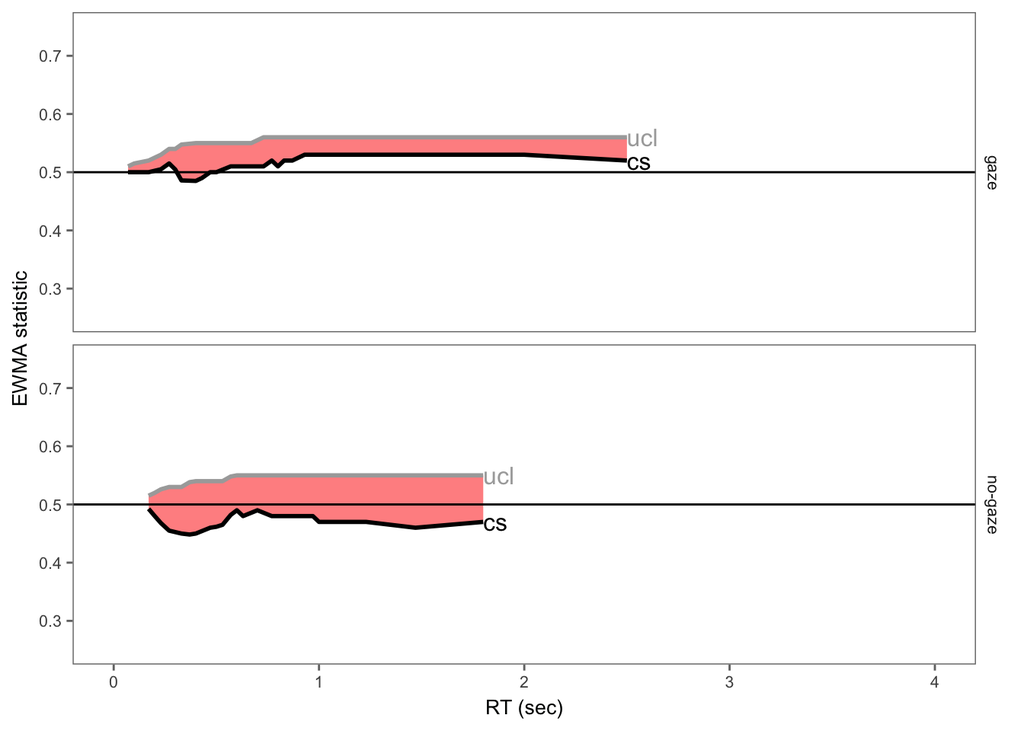

```r
control_chart <- aggregate_ewma(ewma_results)
ribbons <- make_ribbons(control_chart$ewma_summary, control_chart$cutoff_summary)
# plot
control_chart$ewma_summary %>%
  ggplot(aes(x = rt, y = mean_param, color = ewma_param)) +
  geom_ribbon(aes(ymin = cs, ymax = ucl, x = rt), fill = "red", alpha = 0.3,
                data = ribbons$green,
                inherit.aes = F) +
  geom_ribbon(aes(ymin = cs, ymax = ucl, x = rt), fill = "red", alpha = 0.3,
                data = ribbons$green,
                inherit.aes = F) +
  geom_line(size = 1) +
  geom_hline(yintercept = 0.5, linetype = "solid") +
  labs(x = "RT (sec)", y = "EWMA statistic") +
  guides(color=F) +
  xlim(0, 4) +
  ylim(0.25, 0.75) +
  facet_grid(condition~.) +
  scale_color_manual(values = c("black", "darkgrey")) +
  geom_dl(aes(label = ewma_param), method = "last.bumpup") +
  ggthemes::theme_few() +
  theme(text = element_text(size = 10))
```

No evidence of non-guessing signal at any point in the RT distribution for either condition. This isn’t crazy since participants are just learning these words and they didn’t really have time to encode the location of the objects prior to the onset of the novel noun.